# Reproducible Projects in R

# Getting started with R + Rstudio

First steps:

1. **Download and install R:** [CRAN = the Comprehensive R Archive Network](https://cran.r-project.org/)
2. **Download and install Rstudio:** https://posit.co/download/rstudio-desktop/
   - Rstudio = an interactive development environment (IDE) or “front end”, R comes with it’s own, but this one is better!
3. Install the `tidyverse`: an “opinionated [**collection of R packages**](https://tidyverse.org/packages) designed for data science”

```r
# I'll demo multiple ways to do this, starting with
install.packages("tidyverse")
```

If you need a crash course in R, there are lot’s of places to start. Here are some suggestions:

- **R for Data Science (https://r4ds.had.co.nz/)**:  
  As the Rstudio / Tidyverse team recommends here (https://www.tidyverse.org/learn/), this book is “the best place to start learning the tidyverse”. Just about anyone should be able to (1) read the brief introduction and (2) look over the table of contents and quickly find a starting point that meets their level / interest.
- **RStartHere (https://github.com/rstudio/RStartHere).**  
  This is basically a list or compendium of functions/packages in R with the uniquely useful feature of being organized according to the “Data Science Workflow” presented in R for Data Science (https://r4ds.had.co.nz/explore-intro.html).

# Quarto Projects

- `Rmd` and `Qmd`: Rmarkdown and Quarto markdown files
  - These are plain text files
  - For “literate programming”.
  - They are good for communicating! They combine the narrative + display the code + the the results of it’s execution in a unified, reproducible report format.
  - They display format-able text, and syntax-highlighted *executable* code.
  - They can be compiled (“knitted”) into various output formats (e.g. PDF, html)
  - You are reading an HTML file compiled from a `.qmd` document.
  - “the next generation of R Markdown”
- Includes support for
  - LaTeX math! ($y=X\beta + \epsilon$)
  - Referencing (figures, literature, web)

## Create a Quarto Project

To start things off, let’s everyone create a new project within which to work/learn.

- Rstudio > File > New Quarto Project > New Directory > “New Project Wizard” opens

[figure not shown]

[figure not shown]

## How it works

Let me show you how you can use Quarto.

[figure not shown]

- Open the `.qmd` file created with same name as the project
  - When you’ve got multiple files open, Rstudio can store this information when you close
  - You can double click the “.Rproj” to open the project in the state you left it!

### YAML

- The file starts with a `yaml` “header” between two “—”
  - Defines format, behavior, rendered appearance
  - Also defines things like:
    - title
    - author
    - format
    - editor
- There is also a project-wide `yaml` file `_quarto.yml`.
  - You can control overall format and behavior with it.
  - It’s also where you can build out a Navigation bar if you have multiple linked pages in your project.

```yaml
---
project:
  title: "linear_models_intro"

editor: visual

format:
  html:
    toc: true
    embed-resources: true
    self-contained-math: true
---
```

### Markdown

For the authoritative documentation: https://quarto.org/docs/authoring/markdown-basics.html

- Formatting text
  - Headings using (e.g. `#`, `##`, `###`)
    - Different from “COMMENTING” out code lines
  - **Bolds** (with `**`) and *italics* (`*`).
  - LaTeX math

### LaTeX math

- Inline with (`$`)
- Full display on own line with (`$$`)

A superscript with (`^`), and underscore with (`_`)

Example `\sigma^2_e` renders as $\sigma^2_e$

You can do more complicated super/subscripts, like so:

`x_{a^{b-c}}` becomes

$$x_{a^{b-c}}$$

While `\frac{cov(x,y)}{var(x)} = \hat{\beta}` renders as

$$\frac{cov(x,y)}{var(x)} = \hat{\beta}$$

And much more.

There are plug-ins for Word and Google Docs that can read/render LaTeX equations.

### Code chunks

In your `.qmd` file, type **`Cmd + Option + I`** (Mac) or **`Ctrl + Alt + I`** (Win).

Should create a “code chunk”, like this:

````markdown
```{r}
# code here
```
````

- Note the “Play” and other config. buttons

### Rendering

- Save and press the “Render” button

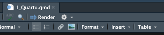

- **NOTE on Rendering Quarto Markdown:** Rendering runs all code chunks. If you have a long-running, resource intensive project, structure it to avoid running that part during render. Use “````{r, eval=FALSE}`”.

## Visual vs. Source Editor

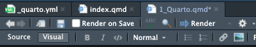

At the top left. Two options.

Other navigation pro-tips

- The “Outline” tab in the Editor (top right)

[figure not shown]

- Code folding

# Reproducible Project Guidelines

**File / Folder Organization**

No “best” way

1. Project in its own self-named directory
2. Document directory
   - `analyses/` for `.qmd`
   - `docs/` for compiled formats, could also include google/word docs
   - `data/` possibly with `raw`, `processed`, `meta` sub-directories
   - `output/` results of models, tables, compiled data ‘products’
   - `code/` for scripts (if not within Rmd/Qmd)
3. Name files well (to reflect content-and-function)
4. Others
   - `README`, `LICENSE`, `CITATION`

**Good File Naming**

- **Machine-readable**
  - Friendly for searching (using regular expressions/globbing)
    - No spaces, unsupported punctuation, accented characters, or case-sensitive file names
  - Friendly for computing
    - Deliberate use of delimiters (i.e., for splitting file names)
      - `data-analyses-fig1.R` with `-` used consistently as a separator
- **Human-readable**
  - Name contains a brief description of the content
  - Borrow from clean URL practices:
    - “slug,” i.e., the part of a URL that is human-readable
      - i.e. `data-analyses-fig1.R`
- Name files considering machine sorting

**Relative Paths**

- Since your whole analysis fits in the project directory, it’s “portable”
- Code paths can be “relative”
- This: `df <- read.csv("../data/foodchoice_budgetlines.csv")`
- Versus this: `df <- read.csv("C:/Users/wilma/Desktop/project23/data/foodchoice_budgetlines.csv")`
- Look `here`! There’s a handy package… it works kinda like a combo of `paste()` and `getwd()` for constructing paths to files.

```r
here::here()
```

```r
here::here("data.csv")
```

**Treat Data as Read Only**

- Or, as we say in my lab “No Excel!”
- Modify only with code. Do not overwrite. Export a “processed” file.

**Generated Output Is Disposable**

- You can regenerate it.
- Output to the `output` folder

**Include a README**

- I’ve rarely done this.
- Should be a plain text file.
- Explain purpose of directory / project.
- Explain contents of data files.
  - How are they formatted?
  - What do each of the columns mean?

**Storage**

- 3-2-1 principle (3 copies, on 2 different media, 1 offsite)
  - My set-up: laptop + Google Drive + Back-up drive
- Keep it in the cloud (e.g. Google Drive)
  - Exclude data (find it alt. back-up) when too big
- Use Git, GitHub for Version Control (another lesson)

**Project Environments**

- `renv`, `packrat`
- Docker

# Organize your own project

- Create `data/` and `output/` directories

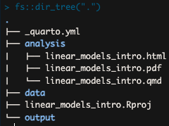

# First steps with R

## Objects and data structures

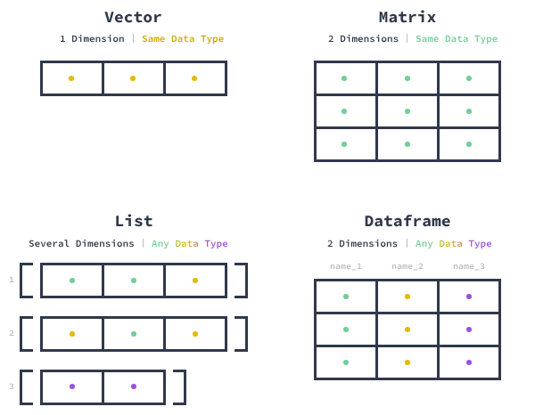

Figure 1: R Data structures – figure from https://www.dataquest.io/

### Vectors

```r
# Atomic vectors
x = c(1,2,3,4,5,6) # numerical vector
x1 = c(1.2, 1.3,1.8, 2.9, 10.5,0.9) # numerical vectors
y <- c("A", "B", "A") # character vector
z = c(TRUE, TRUE, FALSE, FALSE) # logical vector

dim(x)
```

[output not shown]

```r
as.matrix(x)
```

```
     [,1]
[1,]    1
[2,]    2
[3,]    3
[4,]    4
[5,]    5
[6,]    6
```

```r
dim(as.matrix(x))
```

```
[1] 6 1
```

Vectors may only have one type.

### Matrices

```r
# Matrix: vectors in more than one dimension
X <- matrix(c(1, 0,
              1, 1,
              1, 0), nrow = 3, byrow = TRUE)

X
```

```
     [,1] [,2]
[1,]    1    0
[2,]    1    1
[3,]    1    0
```

```r
dim(X)
```

```
[1] 3 2
```

Matrices can *also* only have one type or the other (char, num, logi).

### data.frames

```r
df <- data.frame(y = c(10, 12, 11),
                 geno = factor(c("G1", "G2", "G1")),
                 block = factor(c(1, 1, 2)))
str(df)
```

```
'data.frame':   3 obs. of  3 variables:
 $ y    : num  10 12 11
 $ geno : Factor w/ 2 levels "G1","G2": 1 2 1
 $ block: Factor w/ 2 levels "1","2": 1 1 2
```

- Columns = variables
- Rows = observations
- mixed variable types
- Technically, a special case of a list

```r
# Example in Genomics
x = c("snp1","snp2", "snp3", "snp4", "snp5", "snp6")
y = c(1,1,2,2,3,3)
z = c(10,20,100,400,150,200)
ind1 = c("AA", "AA", "aa", "Aa", "aa", "AA")
ind2 = c("AA", "AA", "aa", "Aa", "AA", "AA")
ind3 = c("Aa", "AA", "aa", "Aa", "Aa", "aa")
ind4 = c("aa", "AA", "Aa", "aa", "AA", "AA")

snp_data = data.frame(name = x,chr = y,pos = z,ind1,ind2,ind3,ind4)
snp_data
```

```
  name chr pos ind1 ind2 ind3 ind4
1 snp1   1  10   AA   AA   Aa   aa
2 snp2   1  20   AA   AA   AA   AA
3 snp3   2 100   aa   aa   aa   Aa
4 snp4   2 400   Aa   Aa   Aa   aa
5 snp5   3 150   aa   AA   Aa   AA
6 snp6   3 200   AA   AA   aa   AA
```

### Factors

```r
levels(df$geno)
```

```
[1] "G1" "G2"
```

Factors add a layer of information (an attribute) called `levels()`.

Use them *ONLY* for specific purposes to avoid undesired behavior.

Containers for *anything*. Mix any type.

```r
m <- lm(y ~ geno + block, data = df)
str(m)
```

```
List of 13
 $ coefficients : Named num [1:3] 10 2 1
  ..- attr(*, "names")= chr [1:3] "(Intercept)" "genoG2" "block2"
 $ residuals    : Named num [1:3] 0 0 0
  ..- attr(*, "names")= chr [1:3] "1" "2" "3"
 $ effects      : Named num [1:3] -19.053 -1.225 0.707
  ..- attr(*, "names")= chr [1:3] "(Intercept)" "genoG2" "block2"
 $ rank         : int 3
 $ fitted.values: Named num [1:3] 10 12 11
  ..- attr(*, "names")= chr [1:3] "1" "2" "3"
 $ assign       : int [1:3] 0 1 2
 $ qr           :List of 5
  ..$ qr   : num [1:3, 1:3] -1.732 0.577 0.577 -0.577 -0.816 ...
  .. ..- attr(*, "dimnames")=List of 2
  .. .. ..$ : chr [1:3] "1" "2" "3"
  .. .. ..$ : chr [1:3] "(Intercept)" "genoG2" "block2"
  .. ..- attr(*, "assign")= int [1:3] 0 1 2
  .. ..- attr(*, "contrasts")=List of 2
  .. .. ..$ geno : chr "contr.treatment"
  .. .. ..$ block: chr "contr.treatment"
  ..$ qraux: num [1:3] 1.577 1.966 0.707
  ..$ pivot: int [1:3] 1 2 3
  ..$ tol  : num 1e-07
  ..$ rank : int 3
  ..- attr(*, "class")= chr "qr"
 $ df.residual  : int 0
 $ contrasts    :List of 2
  ..$ geno : chr "contr.treatment"
  ..$ block: chr "contr.treatment"
 $ xlevels      :List of 2
  ..$ geno : chr [1:2] "G1" "G2"
  ..$ block: chr [1:2] "1" "2"
 $ call         : language lm(formula = y ~ geno + block, data = df)
 $ terms        :Classes 'terms', 'formula'  language y ~ geno + block
  .. ..- attr(*, "variables")= language list(y, geno, block)
  .. ..- attr(*, "factors")= int [1:3, 1:2] 0 1 0 0 0 1
  .. .. ..- attr(*, "dimnames")=List of 2
  .. .. .. ..$ : chr [1:3] "y" "geno" "block"
  .. .. .. ..$ : chr [1:2] "geno" "block"
  .. ..- attr(*, "term.labels")= chr [1:2] "geno" "block"
```

[output cut: 11 more lines]

```
  ..- attr(*, "terms")=Classes 'terms', 'formula'  language y ~ geno + block
  .. .. ..- attr(*, "variables")= language list(y, geno, block)
  .. .. ..- attr(*, "factors")= int [1:3, 1:2] 0 1 0 0 0 1
  .. .. .. ..- attr(*, "dimnames")=List of 2
  .. .. .. .. ..$ : chr [1:3] "y" "geno" "block"
  .. .. .. .. ..$ : chr [1:2] "geno" "block"
  .. .. ..- attr(*, "term.labels")= chr [1:2] "geno" "block"
  .. .. ..- attr(*, "order")= int [1:2] 1 1
  .. .. ..- attr(*, "intercept")= int 1
  .. .. ..- attr(*, "response")= int 1
  .. .. ..- attr(*, ".Environment")=<environment: R_GlobalEnv>
  .. .. ..- attr(*, "predvars")= language list(y, geno, block)
  .. .. ..- attr(*, "dataClasses")= Named chr [1:3] "numeric" "factor" "factor"
  .. .. .. ..- attr(*, "names")= chr [1:3] "y" "geno" "block"
 - attr(*, "class")= chr "lm"
```

# Sub-setting the Data

Indices (the positioning system used for the dimensions of objects).

R is 1-based (starts at 1)

## Base R

Vectors

```r
y[1]
```

```
[1] 1
```

```r
z[2:3]
```

```
[1]  20 100
```

```r
z[-c(1:5)]
```

```
[1] 200
```

Matrices

`matrix[row,column]`

```r
X[1:2,]
```

```
     [,1] [,2]
[1,]    1    0
[2,]    1    1
```

data.frames

```r
df[1,2]
```

```
[1] G1
Levels: G1 G2
```

```r
df$geno
```

```
[1] G1 G2 G1
Levels: G1 G2
```

```r
df[["geno"]]
```

```
[1] G1 G2 G1
Levels: G1 G2
```

```r
df[["geno"]][1]
```

```
[1] G1
Levels: G1 G2
```

Lists

```r
m$coefficients
```

```
(Intercept)      genoG2      block2
         10           2           1
```

```r
m[1:2]
```

```
$coefficients
(Intercept)      genoG2      block2
         10           2           1

$residuals
1 2 3
0 0 0
```

```r
m[1:2][["residuals"]]
```

```
1 2 3
0 0 0
```

```r
m[1:2][["residuals"]][1]
```

```
1
0
```

## tidyverse style - dplyr + `%>%`

Let’s add to the tool set.

The “tidyverse” series of package provides a huge amount of utility for clear, human-readable programming. You’ll learn it well following “[R for Data Science](https://r4ds.hadley.nz/)”.

```r
library(tidyverse)
```

First `magrittr`’s “pipe” function (`%>%`).

[figure not shown]

[figure not shown]

- `x %>% f` is equivalent to `f(x)`
- `x %>% f(y)` is equivalent to `f(x, y)`
- `x %>% f %>% g %>% h` is equivalent to `h(g(f(x)))`

The left-hand side is evaluated first, then passed as input to the right-hand side.

An argument placeholder exists to direct the input from left into the right side function. - `x %>% f(y, .)` is equivalent to `f(y, x)` - `x %>% f(y, z = .)` is equivalent to `f(y, z = x)`

**Keyboard Shortcut:** Type `CMD + Shift + M` (Mac) or `CTRL + Shift + M` (Win) to make pipes (`%>%`) easily

```r
sum(snp_data$chr)
```

```
[1] 12
```

```r
# is equivalent to
snp_data$chr %>% sum(.)
```

```
[1] 12
```

```r
# or
snp_data$chr %>% sum # for shortest
```

```
[1] 12
```

Now let’s add `dplyr` (https://dplyr.tidyverse.org/) “a grammar of data manipulation”.

- Cheatsheet: https://biostats.w.uib.no/dplyr-a-simplified-cheat-sheet/
- [`mutate()`](https://dplyr.tidyverse.org/reference/mutate.html) adds new variables that are functions of existing variables
- [`select()`](https://dplyr.tidyverse.org/reference/select.html) picks variables based on their names.
- [`filter()`](https://dplyr.tidyverse.org/reference/filter.html) picks cases based on their values.
- [`summarise()`](https://dplyr.tidyverse.org/reference/summarise.html) reduces multiple values down to a single summary.
- [`arrange()`](https://dplyr.tidyverse.org/reference/arrange.html) changes the ordering of the rows.

Let’s use just `filter()` and `select()` now.

```r
# Filter for subsetting the rows of a data.frame
snp_data %>%
  filter(chr==1,
         pos<100)
# Select to subset the columns and/or reorder them
snp_data %>%
  select(chr,pos,ind2:ind3)

# Combo
snp_data %>%
  # pick out chromosome 2 only
  filter(chr==2) %>%
  # select desired colulmns
  select(chr,pos) %>%
  # grab a single column
  .$pos %>%
  # pass it to a function like summary
  summary
```

[output not shown]

# Matrix operations

## Add/Subtract/Arithmetic

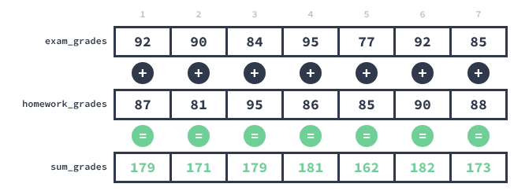

Figure 2: Element-wise operations – figure from https://www.dataquest.io/

```r
4+4 # sum
3/3 # divide
log(10) # natural logarithm
log10(0.01) # base-10 logarithm
exp(2.3) # exponential

# Summary statistics
tmp = c(1,2,3) # example
mean(tmp) # mean
var(tmp) # variance
sum(tmp) # sum

# Summary statistic in data frame
mean(snp_data$pos) # mean of a col in the data frame
var(snp_data$pos) # var of a col in the data frame

# Example from https://www.dataquest.io/
exam_grades <- c(92, 90, 84, 95, 77, 92, 85)
homework_grades <- c(87, 81, 95, 86, 85, 90, 88)
sum_grades = exam_grades+ homework_grades
```

[output not shown]

Recall:

$$y = X\beta + \epsilon$$

## Matrix multiplication

```r
beta <- c(10, 2)

# Matrix multiplication
X %*% beta
```

```
     [,1]
[1,]   10
[2,]   12
[3,]   10
```

```r
beta * beta
```

```
[1] 100   4
```

```r
beta %*% beta
```

```
     [,1]
[1,]  104
```

Cross products and transpose

```r
t(X) %*% X
```

```
     [,1] [,2]
[1,]    3    1
[2,]    1    1
```

```r
t(X) %*% c(10, 12, 11)
```

```
     [,1]
[1,]   33
[2,]   12
```

Inversion

Recall that $A^{-1}A=AA^{-1}=1$ defines an inverse matrix

```r
A<-t(X) %*% X # make a square matrix
A
```

```
     [,1] [,2]
[1,]    3    1
[2,]    1    1
```

```r
# Invert it
Ainv<-solve(A)
Ainv
```

```
     [,1] [,2]
[1,]  0.5 -0.5
[2,] -0.5  1.5
```

```r
A%*%Ainv
```

```
             [,1] [,2]
[1,] 1.000000e+00    0
[2,] 5.551115e-17    1
```

Recall the OLS solution for a linear model:

$$\hat{\beta} = (X^TX)^{-1}X^Ty$$

```r
y <- c(10, 12, 11)
solve(t(X) %*% X) %*% t(X) %*% y
```

```
     [,1]
[1,] 10.5
[2,]  1.5
```

# Take some time

Familiarize yourself with working in Rstudio, with Quarto markdown.

Things you might want to work on:

1. Making code chunks
2. Writing with LaTeX formulas
3. Formatting text with markdown
4. Navigating Rstudio
5. Rendering your QMD
6. Manipulating data with `dplyr`
7. Writing pipelines with `%>%`
8. Vector and Matrix Operations

# Not (yet) covered

- Additional `dplyr` functions
- Plotting with `ggplot`
- Functions
- Loops (with `purrr`)
- The answer to the ultimate question of life, the universe and everything

# References

- https://carpentries-incubator.github.io/reproducible-publications-quarto/index.html
- Isik et al. 2017 - Ch. 2 - A Review of Linear Mixed Models
- Ferrao - MAS - Intro to Linear Models
- Ferrao - QG - WK2a - Why models?